# Chapter6_prac

Xinyu

16/12/2021

```r
# first library a few packages that we will use
# during the practical
library(spatstat)
library(here)
library(sp)
library(rgeos)
```

```r
library(maptools)
library(GISTools)
library(tmap)
library(sf)
library(geojson)
library(geojsonio)
library(tmaptools)
```

# Setting up your data

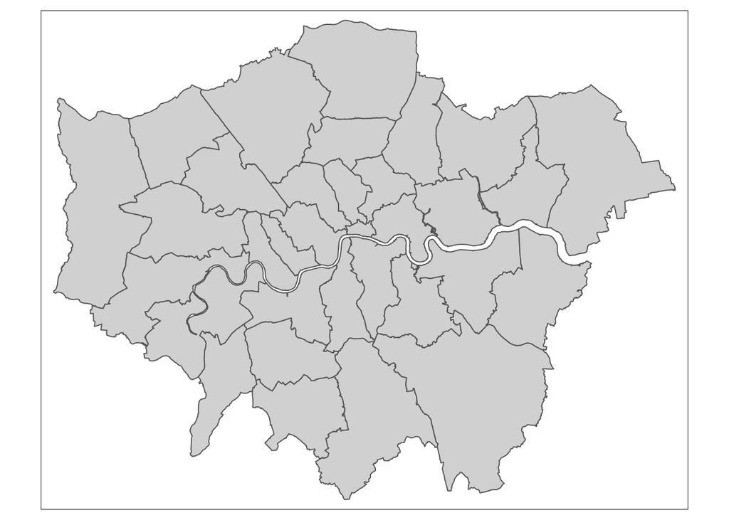

```r
# first, get the london borough boundaries
LondonBoroughs <- st_read(here::here("statistical-gis-boundaries-london/ESRI/London_Borough_Excluding_MHW.shp"))
library(stringr)
BoroughMap <- LondonBoroughs%>%
  dplyr::filter(str_detect(GSS_CODE,"^E09"))%>%
  st_transform(.,27700)
qtm(BoroughMap)
```

```r
summary(BoroughMap)
```

```
##      NAME             GSS_CODE            HECTARES         NONLD_AREA
##  Length:33          Length:33          Min.   :  314.9   Min.   :  0.00
##  Class :character   Class :character   1st Qu.: 2724.9   1st Qu.:  0.00
##  Mode  :character   Mode  :character   Median : 3857.8   Median :  2.30
##                                        Mean   : 4832.4   Mean   : 64.22
##                                        3rd Qu.: 5658.5   3rd Qu.: 95.60
##                                        Max.   :15013.5   Max.   :370.62
##   ONS_INNER           SUB_2009           SUB_2006                  geometry
##  Length:33          Length:33          Length:33          MULTIPOLYGON :33
##  Class :character   Class :character   Class :character   epsg:27700   : 0
##  Mode  :character   Mode  :character   Mode  :character   +proj=tmer...: 0
##
##
##
```

Now get the location of all Blue Plaques in the city

```r
BluePlaques <- st_read("https://s3.eu-west-2.amazonaws.com/openplaques/open-plaques-london-2018-04-08.geojson")%>%
  st_transform(.,27700)
summary(BluePlaques)
```

```
##        id          inscription                 geometry
##  Min.   :    1.0   Length:2812        POINT        :2812
##  1st Qu.:  711.8   Class :character   epsg:27700   :   0
##  Median : 6089.0   Mode  :character   +proj=tmer...:   0
##  Mean   :10622.0
##  3rd Qu.:10358.2
##  Max.   :49190.0
```

Plot the blue plaques in the city

```r
#tmap_mode set to plotting
tmap_mode("plot")
```

```
## tmap mode set to plotting
```

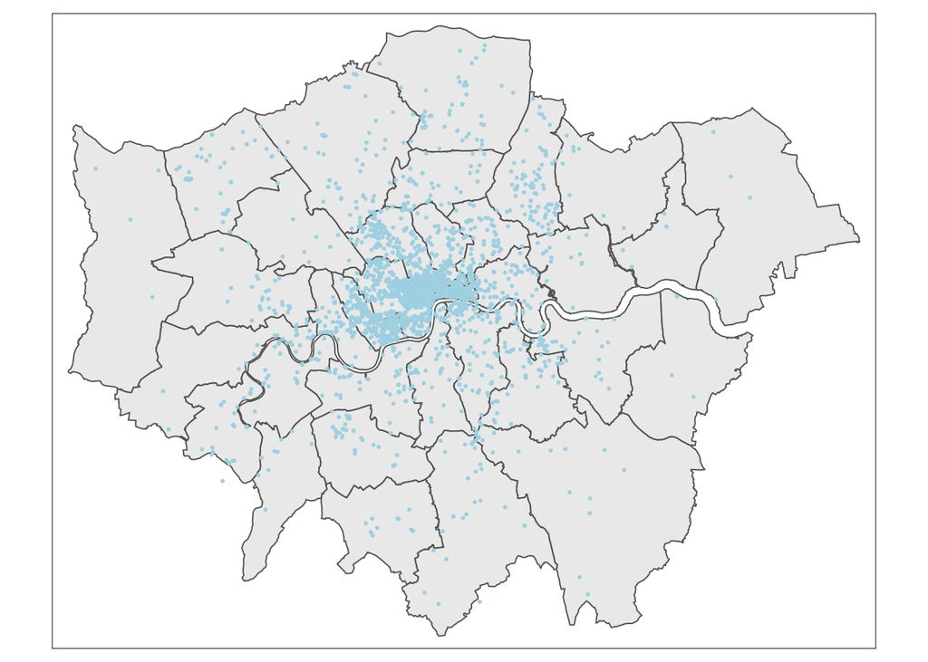

```r
tm_shape(BoroughMap)+
  tm_polygons(col = NA,alpha = 0.5)+
tm_shape(BluePlaques)+
  tm_dots(col = "lightblue")
```

# Data cleaning There is at least one Blue Plaque that falls outside of the Borough boundaries. Errant plaques will cause problems with our analysis, so we need to clip the plaques to the boundaries. First we’ll remove any plaques with the same grid reference as this will cause problems later on the analysis…

```r
library(tidyverse)
BluePlaques <- distinct(BluePlaques)
```

# Spatial subsetting

Now just select the points inside London

```r
BluePlaquesSub <- BluePlaques[BoroughMap,]
# check to see that they've been removed
tmap_mode("plot")
```

```
## tmap mode set to plotting
```

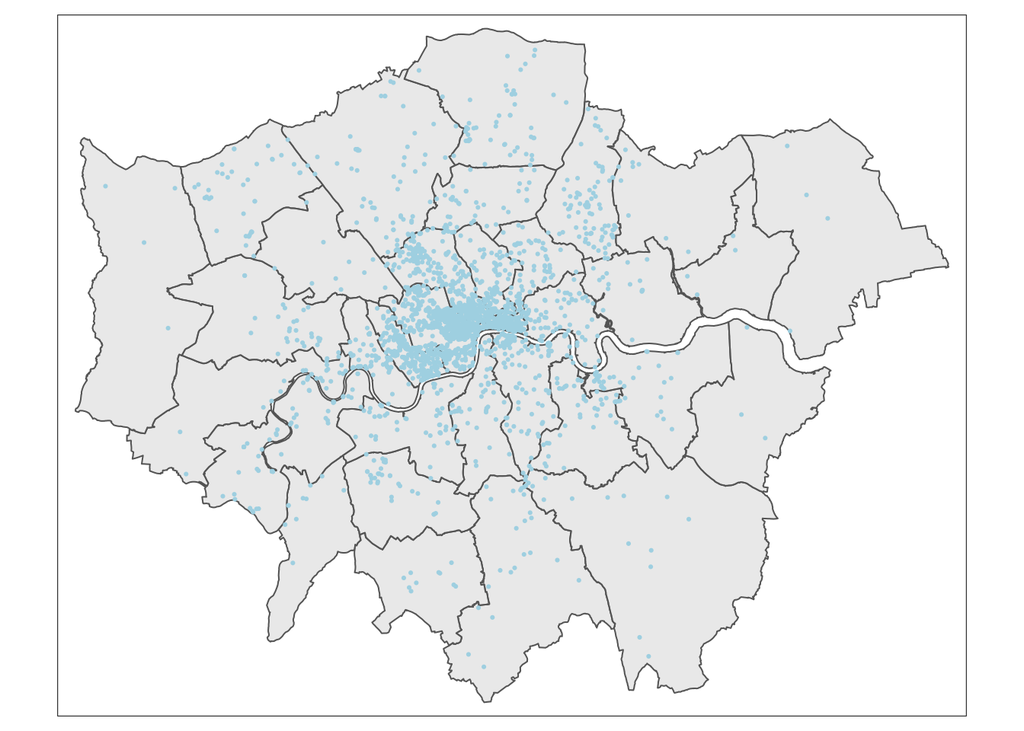

```r
tm_shape(BoroughMap)+
  tm_polygons(col = NA,alpha = 0.5)+
tm_shape(BluePlaquesSub)+
  tm_dots(col = "lightblue")
```

# Study area First we need to subset our sf object to pull out a borough we are interested in. I’m going to choose Harrow as I know there are few enough points for the analysis to definitely work. If you wish, feel free to choose another borough in London and run the same analysis, but beware that if it happens that there are a lot of blue plaques in your borough, the analysis could fall over!!

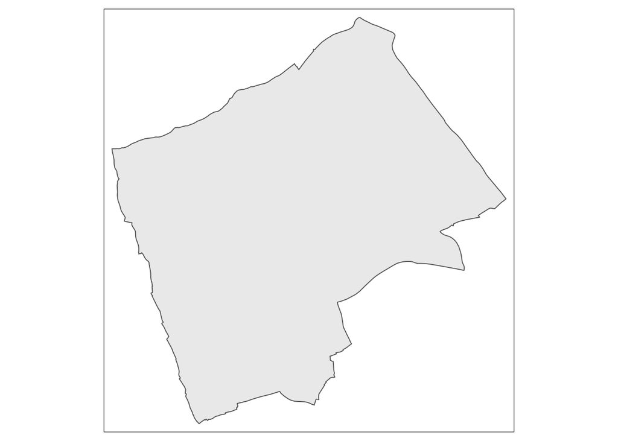

```r
Harrow <- BoroughMap %>%
  filter(.,NAME=="Harrow")
# check to see that the correct borough has been pulled out
tm_shape(Harrow)+
  tm_polygons(col=NA,alpha = 0.5)
```

Now we need to clip out Blue Plaques so that we have a subset of just those that fall within the borough of interest

```r
# clip the data to our sigle borough
BluePlaquesSub <- BluePlaques[Harrow,]
# check that it's worked
tmap_mode("plot")
```

```
## tmap mode set to plotting
```

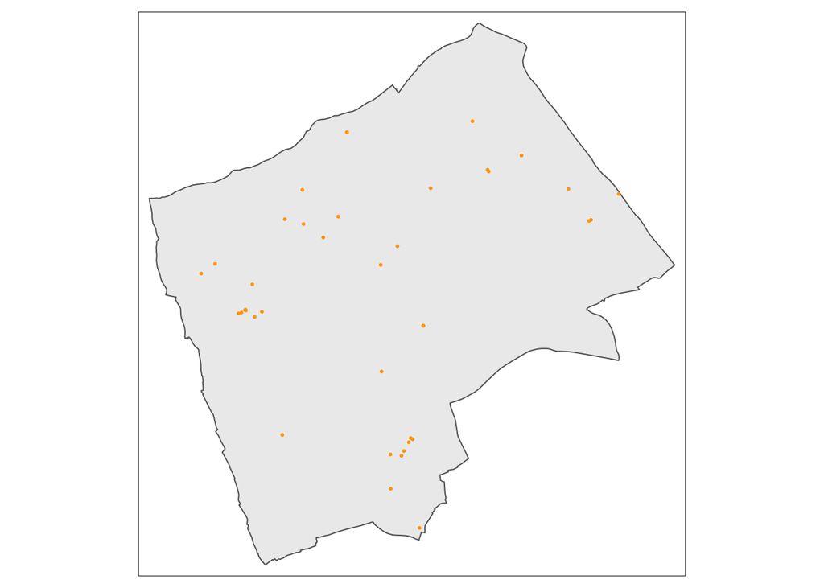

```r
tm_shape(Harrow)+
  tm_polygons(col = NA,alpha = 0.5)+
tm_shape(BluePlaquesSub)+
  tm_dots(col = "orange")
```

We now have all our data so that we can start the analysis using spatstat. The first thing we need to do is create an observation window for spatstat to carry our its analysis within - we will set this to the extent of the Harrow boundary

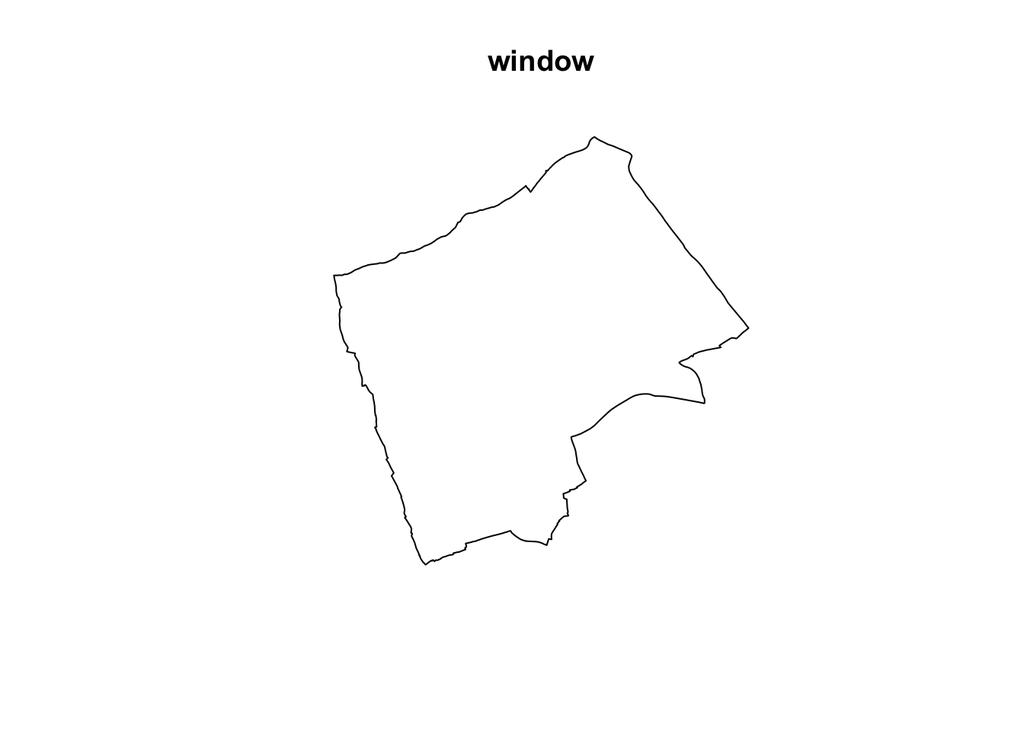

```r
window <- as.owin(Harrow)
plot(window)
```

```r
# create a sp object
BluePlaquesSub <- BluePlaquesSub%>%
  as(.,"Spatial")
# create a ppp object
BluePlaquesSub.ppp <- ppp(x=BluePlaquesSub@coords[,1],
                          y=BluePlaquesSub@coords[,2],
                          window = window)
```

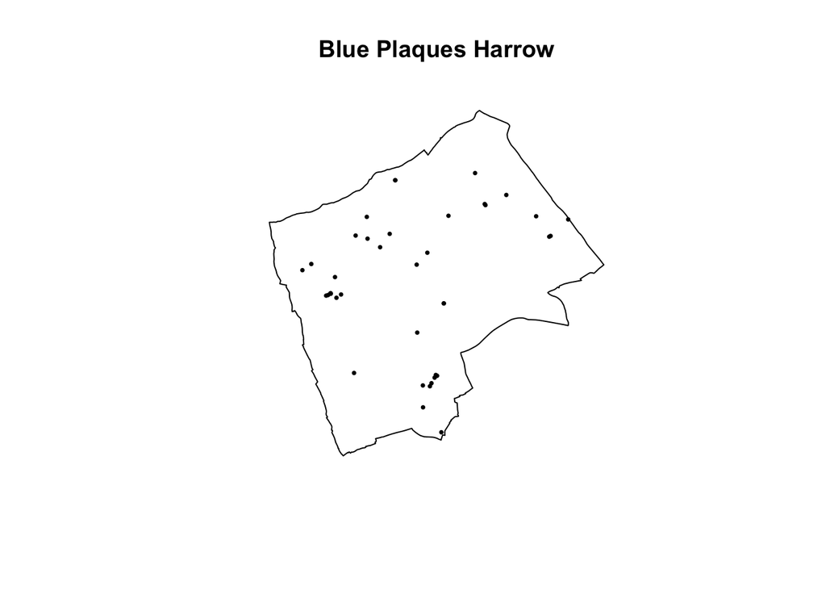

```r
BluePlaquesSub.ppp %>%
  plot(.,pch=16,cex=0.5,
       main="Blue Plaques Harrow")
```

# 6.6 point pattern analysis ## 6.6.1 Kernel Density Estimation

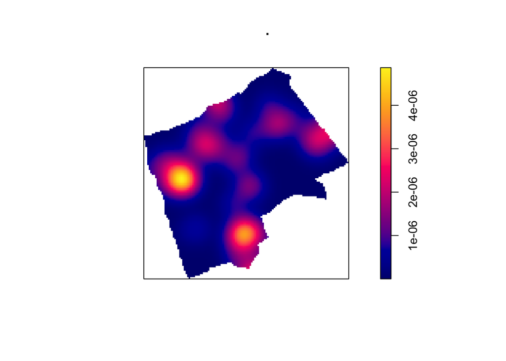

```r
BluePlaquesSub.ppp%>%
  density(.,sigma=500) %>%
  plot()
```

```r
# the sigma value sets the diameter of the Kernel(in the units your map is in - in this case, as we are in British National Grid the units are in metres)
```

# 6.6.2 Quadrat Analysis

What we are interested in is: whether the distribution of points in our study area differs from “complete spatial randomness”-CSR. ! It’s different from CRS !!!!

First plot the points

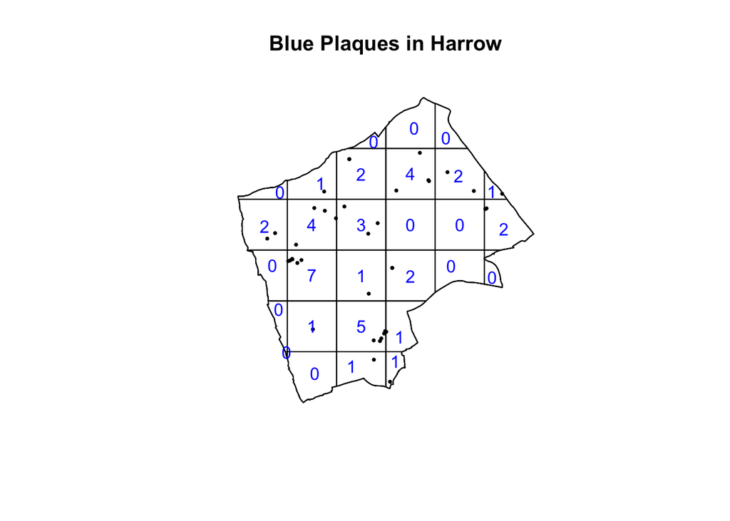

```r
plot(BluePlaquesSub.ppp,
     pch=16,
     cex=0.5,
     main="Blue Plaques in Harrow")
# count the points in that fall in 6 x 6 grid overlaid across the window BluePlaquesSub.ppp
BluePlaquesSub.ppp %>%
  quadratcount(.,nx=6,ny=6)%>%
  plot(.,add=T,col="blue")
```

```r
# run the quadrat count
Qcount <- BluePlaquesSub.ppp %>%
  quadratcount(.,nx=6,ny=6) %>%
  as.data.frame()%>%
  dplyr::count(Var1=Freq)%>%
  dplyr::rename(Freqquadratcount=n)
# check the data type in the first column
# if it is factor we need to convert it to numeric
Qcount%>%
  summarise_all(class)
```

```
##      Var1 Freqquadratcount
## 1 integer          integer
```

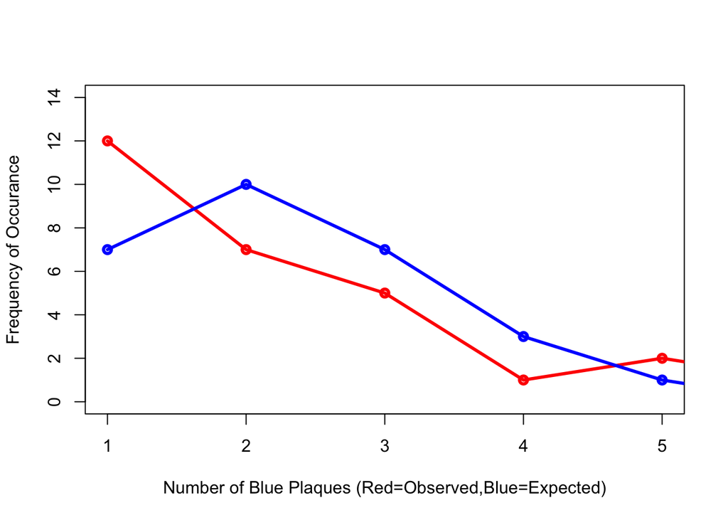

```r
# Now we have a frequency table. Next we need to calculate our expected values. The formula for calculating expected probabilities based on the Poisson distribution.
sums <- Qcount %>%
  #calculate the total blue plaques
  mutate(total=Var1*Freqquadratcount) %>%
  dplyr::summarise(across(everything(),sum))%>%
  dplyr::select(-Var1)
lambda <- Qcount%>%
  #calculate lambda
  mutate(total=Var1*Freqquadratcount)%>%
  dplyr::summarise(across(everything(),sum))%>%
  mutate(lambda=total/Freqquadratcount)%>%
  dplyr::select(lambda)%>%
  pull(lambda)
#Calculate expected using the Poisson formula from above  k is the number of blue plaques counted in a square and is found in the first column of our table…

QCountTable <- Qcount %>%
  mutate(Pr=((lambda^Var1)*exp(-lambda))/factorial(Var1))%>%
  #now calculate the expected counts based on our total number of plaques and save them to the table
  mutate(Expected=(round(Pr*sums$Freqquadratcount,0)))

# compare the frequency distributions of the observed and expected point pattern
plot(c(1,5),c(0,14),type="n",
     xlab="Number of Blue Plaques (Red=Observed,Blue=Expected)",
     ylab="Frequency of Occurance")
points(QCountTable$Freqquadratcount,
       col="Red",type="o",lwd=3)
points(QCountTable$Expected,col="Blue",type="o",lwd=3)
```

```r
teststats <- quadrat.test(BluePlaquesSub.ppp, nx = 6, ny = 6)
```

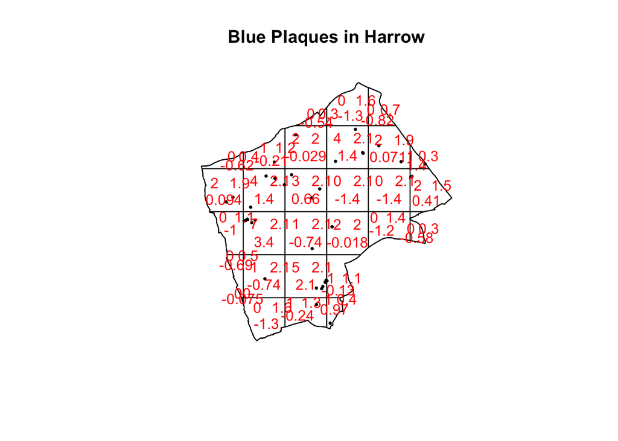

```r
plot(BluePlaquesSub.ppp,pch=16,cex=0.5, main="Blue Plaques in Harrow")
plot(teststats, add=T, col = "red")
```

# Ripley’s K

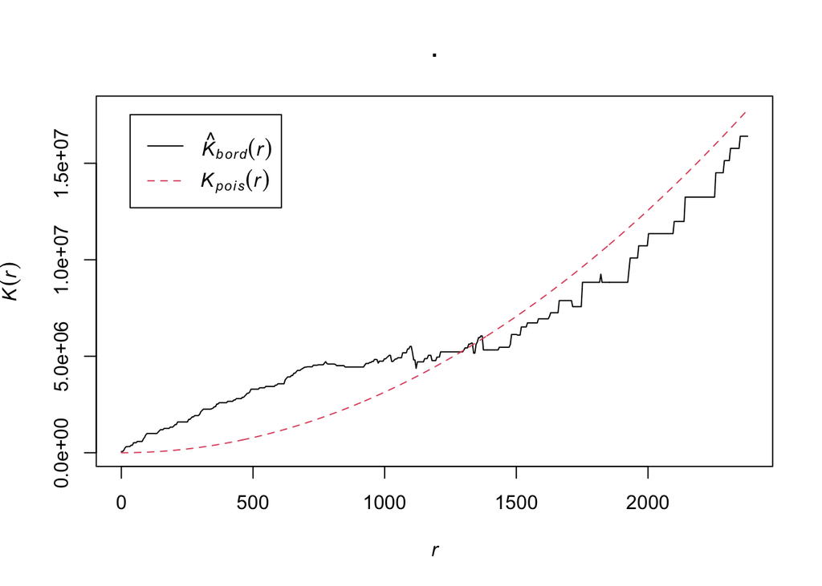

```r
K <- BluePlaquesSub.ppp %>%
  Kest(., correction="border") %>%
  plot()
```

```r
Kval <- as.data.frame(Kest(BluePlaquesSub.ppp, correction = "border"))
```

# Density-based spatial clustering of applications with noise: DBSCAN

```r
library(raster)
library(fpc)
# we will now carry out a DBSCAN analysis of blue plaques in my borough to see if there are any clusters present

#first check the coordinate reference system of the Harrow spatial polygon:
st_geometry(BoroughMap)
```

```
## Geometry set for 33 features
## Geometry type: MULTIPOLYGON
## Dimension:     XY
## Bounding box:  xmin: 503568.2 ymin: 155850.8 xmax: 561957.5 ymax: 200933.9
## Projected CRS: OSGB 1936 / British National Grid
## First 5 geometries:
```

```
## MULTIPOLYGON (((516401.6 160201.8, 516407.3 160...
```

```
## MULTIPOLYGON (((535009.2 159504.7, 535005.5 159...
```

```
## MULTIPOLYGON (((540373.6 157530.4, 540361.2 157...
```

```
## MULTIPOLYGON (((521975.8 178100, 521967.7 17809...
```

```
## MULTIPOLYGON (((510253.5 182881.6, 510249.9 182...
```

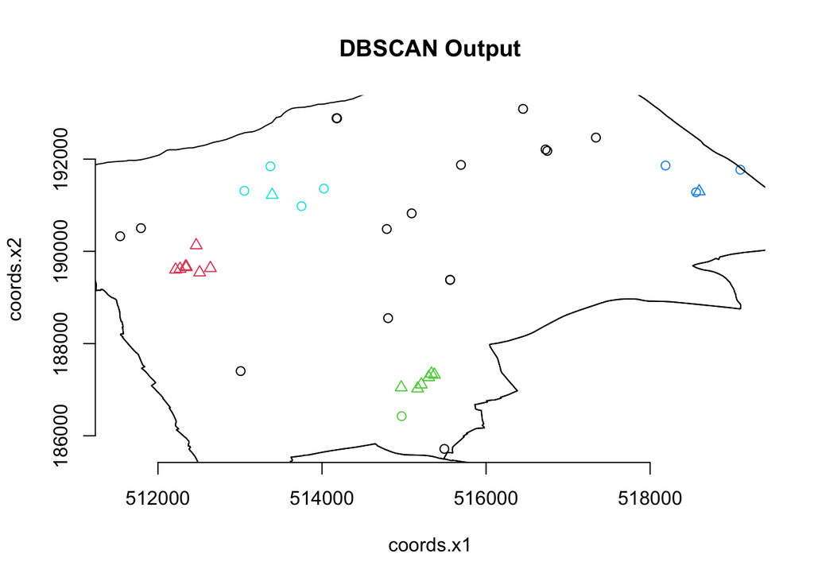

```r
#first extract the points from the spatial points data frame
BluePlaquesSubPoints <- BluePlaquesSub %>%
  coordinates(.)%>%
  as.data.frame()

# now run the dbscan analysis
db <- BluePlaquesSubPoints %>%
  fpc::dbscan(.,eps = 700,MinPts = 4)
# now plot the results
plot(db, BluePlaquesSubPoints, main = "DBSCAN Output", frame = F)
plot(BoroughMap$geometry, add=T)
```

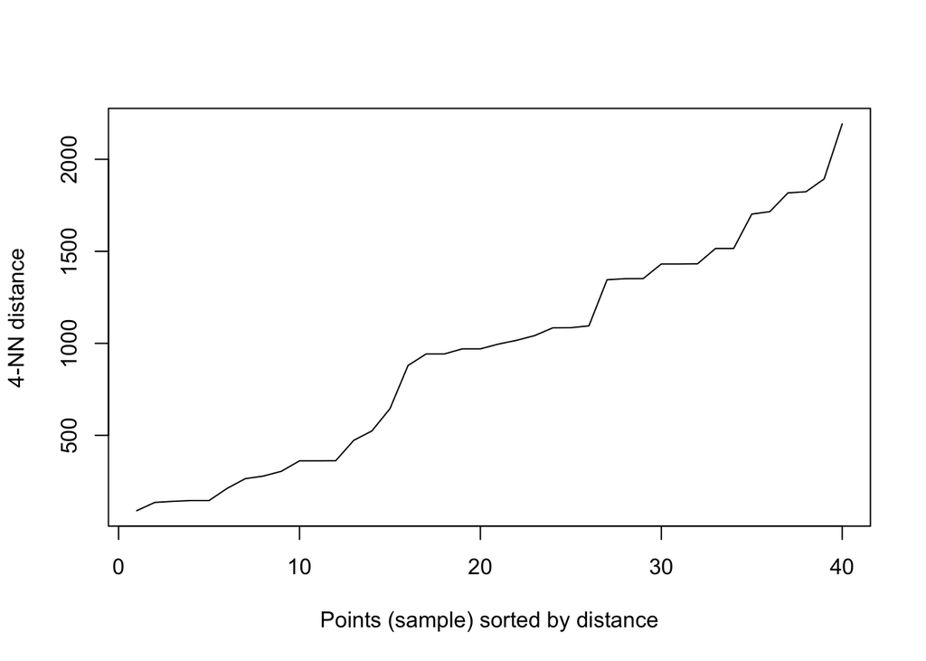

```r
# used to find suitable eps value based on the knee in plot
# k is no. of nearest neighbours used,use min points
library(dbscan)
BluePlaquesSubPoints%>%
  dbscan::kNNdistplot(.,k=4)
```

```r
# we can always produce a much nicer plot by extracting the useful information from the DBSCAN output and use ggplot2 to produce a much cooler map
library(ggplot2)
db
```

```
## dbscan Pts=40 MinPts=4 eps=700
##         0 1 2 3 4
## border 16 0 1 3 4
## seed    0 8 6 1 1
## total  16 8 7 4 5
```

```r
db$cluster
```

```
##  [1] 2 1 2 0 1 0 1 0 2 3 2 1 0 4 0 2 0 0 0 4 2 4 1 0 4 3 0 0 4 0 0 2 0 3 1 0 0 3
## [39] 1 1
```

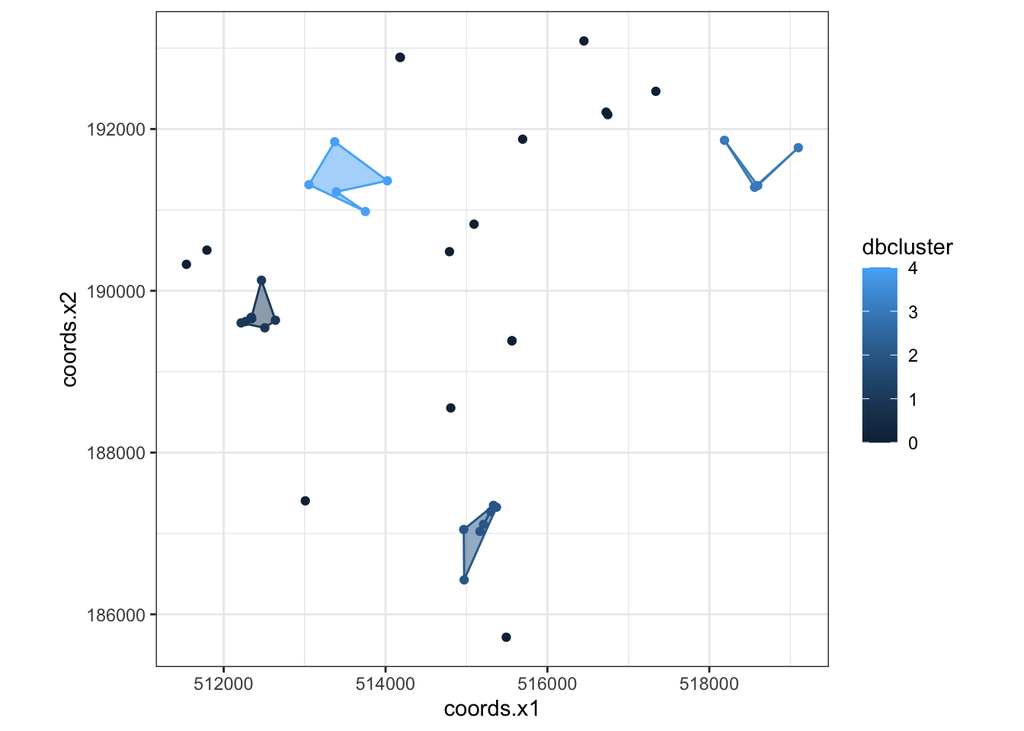

```r
# We can now add this cluster membership info back into our dataframe
BluePlaquesSubPoints<- BluePlaquesSubPoints %>%
  mutate(dbcluster=db$cluster)
#Next we are going to create some convex hull polygons to wrap around the points in our clusters.
chulls <- BluePlaquesSubPoints %>%
  group_by(dbcluster) %>%
  dplyr::mutate(hull = 1:n(),
  hull = factor(hull, chull(coords.x1, coords.x2)))%>%
  arrange(hull)
# As 0 isn’t actually a cluster (it’s all points that aren’t in a cluster) drop it from the dataframe
chulls <- chulls %>%
  filter(dbcluster >=1)

# Now create a ggplot2 object from our data
dbplot <- ggplot(data=BluePlaquesSubPoints,
                 aes(coords.x1,coords.x2, colour=dbcluster, fill=dbcluster))
#add the points in
dbplot <- dbplot + geom_point()
#now the convex hulls
dbplot <- dbplot + geom_polygon(data = chulls,
                                aes(coords.x1,coords.x2, group=dbcluster),
                                alpha = 0.5)
#now plot, setting the coordinates to scale correctly and as a black and white plot
#(just for the hell of it)...
dbplot + theme_bw() + coord_equal()
```

```r
###add a basemap
##First get the bbox in lat long for Harrow
HarrowWGSbb <- Harrow %>%
  st_transform(., 4326)%>%
  st_bbox()
# Now convert the basemap to British National Grid

library(OpenStreetMap)

basemap <- OpenStreetMap::openmap(c(51.5549876,-0.4040502),c(51.6405356,-0.2671315),
                         zoom=NULL,
                         "stamen-toner")
  # convert the basemap to British National Grid
basemap_bng <- openproj(basemap, projection="+init=epsg:27700")
```

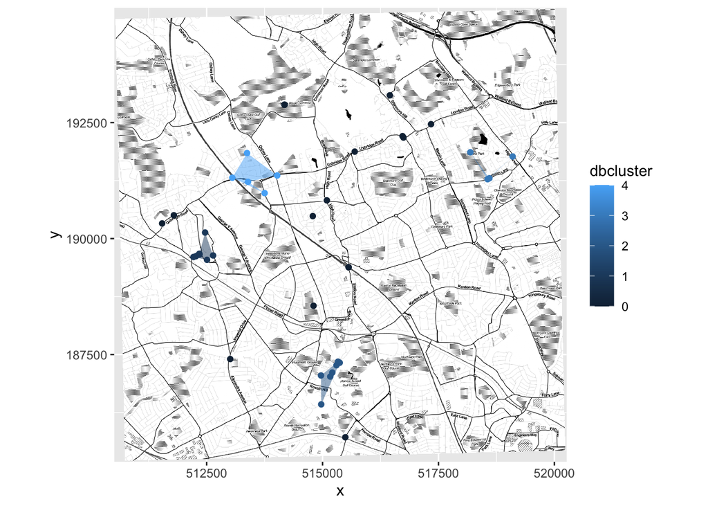

```r
# Now we can plot our fancy map with the clusters on…

#autoplot(basemap_bng) sometimes works
autoplot.OpenStreetMap(basemap_bng)+
  geom_point(data=BluePlaquesSubPoints,
             aes(coords.x1,coords.x2,
                 colour=dbcluster,
                 fill=dbcluster)) +
  geom_polygon(data = chulls,
               aes(coords.x1,coords.x2,
                   group=dbcluster,
                   fill=dbcluster),
               alpha = 0.5)
```